# animeproje

Group Project / Honey Drip Group Members : Egemen Onat Atam, Uğur Özata, Bayram Saygılı, Yaser Girit, Bengü Üzmez Introduction Anime has a large and dedicated following all over the world, and understanding the preferences and behaviors of anime fans can be valuable for industry professionals and researchers alike. In this project, we will be working with five datasets related to anime that are available on Kaggle. The datasets contain information on anime titles, genres, ratings, synopsis, and user behavior. By applying statistical and data mining techniques, we aim to extract insights and identify trends and patterns within the anime community.

The specific objectives of this project are to:

Explore the characteristics of popular anime titles Identify factors that contribute to high ratings for anime Analyze the preferences of anime fans based on their ratings and watching habits Understand the dynamics of the anime community by analyzing user behavior data We will begin by providing a detailed description of the datasets and the data cleaning and preprocessing steps that were taken. The main analysis and findings will be presented in the subsequent sections, followed by a conclusion and recommendations for further study. Through this project, we hope to gain a better understanding of the anime community and provide valuable insights for professionals and researchers.

Data Cleaning and Preprocessing: Before we can begin our analysis, it is important to ensure that the data is clean and ready for processing. The first step in this process is to split the "Aired" column into "start_date" and "end_date" columns, and convert them to datetime format. We will also drop the original "Aired" column.

Once the data has been cleaned and preprocessed, we can begin the analysis. We will start by exploring the characteristics of popular anime titles, including their genres, ratings, and other factors that may contribute to their popularity. We will also analyze the preferences of anime fans based on their ratings and watching habits, and understand the dynamics of the anime community by analyzing user behavior data.

```python
import pandas as pd
import matplotlib.pyplot as plt
import seaborn as sns
anime = pd.read_csv("C:/Users/USER/Desktop/anime.csv")
# Split the "aired" column into two columns using the "to" delimiter
anime[["start_date", "end_date"]] = anime["Aired"].str.split(" to ", expand=True)
anime["start_date"] = pd.to_datetime(anime["start_date"], errors="coerce")
anime["end_date"] = pd.to_datetime(anime["end_date"], errors="coerce")
# Drop the original "aired" column
anime = anime.drop("Aired", axis=1)
# Replace the "Unknown" values with NaN
anime = anime.replace('Unknown', float('nan'))

# Convert the Score, Ranked, Rating, and Members columns to integers
anime['Score'] = pd.to_numeric(anime['Score'], downcast='integer')
anime['Ranked'] = pd.to_numeric(anime['Ranked'], downcast='integer')
anime['Members'] = pd.to_numeric(anime['Members'], downcast='integer')
anime['Episodes'] = pd.to_numeric(anime['Episodes'], downcast='integer')
# Convert the Score-1 to Score-10 columns to integers
for i in range(1, 11):
    column_name = f'Score-{i}'
    anime[column_name] = pd.to_numeric(anime[column_name], downcast='integer')
anime.head(1)
```

|  | MAL_ID | Name | Score | Genres | English name | Japanese name | Type | Episodes | Premiered | Producers | ... | Score-8 | Score-7 | Score-6 | Score-5 | Score-4 | Score-3 | Score-2 | Score-1 | start_date | end_date |
| --- | --- | --- | --- | --- | --- | --- | --- | --- | --- | --- | --- | --- | --- | --- | --- | --- | --- | --- | --- | --- | --- |
| 0 | 1 | Cowboy Bebop | 8.78 | Action, Adventure, Comedy, Drama, Sci-Fi, Space | Cowboy Bebop | カウボーイビバップ | TV | 26.0 | Spring 1998 | Bandai Visual | ... | 131625.0 | 62330.0 | 20688.0 | 8904.0 | 3184.0 | 1357.0 | 741.0 | 1580.0 | 1998-04-03 | 1999-04-24 |

1 rows × 36 columns

```python
anime.info()
```

```
<class 'pandas.core.frame.DataFrame'>
RangeIndex: 17562 entries, 0 to 17561
Data columns (total 36 columns):
 #   Column         Non-Null Count  Dtype
---  ------         --------------  -----
 0   MAL_ID         17562 non-null  int64
 1   Name           17562 non-null  object
 2   Score          12421 non-null  float64
 3   Genres         17499 non-null  object
 4   English name   6997 non-null   object
 5   Japanese name  17514 non-null  object
 6   Type           17525 non-null  object
 7   Episodes       17046 non-null  float64
 8   Premiered      4745 non-null   object
 9   Producers      9768 non-null   object
```

[output cut: 28 more lines]

```python
%load_ext sql
```

```python
from sqlalchemy import create_engine
```

```python
%sql postgresql://postgres:178956@localhost/deneme
```

```python
%%sql
SELECT * FROM anime
LIMIT 1
```

```
 * postgresql://postgres:***@localhost/deneme
1 rows affected.
```

| mal_id | name | score | genres | english_name | japanese_name | type | episodes | premiered | producers | licensors | studios | source | duration | rating | ranked | popularity | members | favorites | watching | completed | on_hold | dropped | plan_to_watch | score_10 | score_9 | score_8 | score_7 | score_6 | score_5 | … |
| --- | --- | --- | --- | --- | --- | --- | --- | --- | --- | --- | --- | --- | --- | --- | --- | --- | --- | --- | --- | --- | --- | --- | --- | --- | --- | --- | --- | --- | --- | --- |
| 1 | Cowboy Bebop | 8.78 | Action, Adventure, Comedy, Drama, Sci-Fi, Space | Cowboy Bebop | カウボーイビバップ | TV | 26.0 | Spring 1998 | Bandai Visual | Funimation, Bandai Entertainment | Sunrise | Original | 24 min. per ep. | R - 17+ (violence & profanity) | 28.0 | 39 | 1251960 | 61971 | 105808 | 718161 | 71513 | 26678 | 329800 | 229170.0 | 182126.0 | 131625.0 | 62330.0 | 20688.0 | 8904.0 | … |

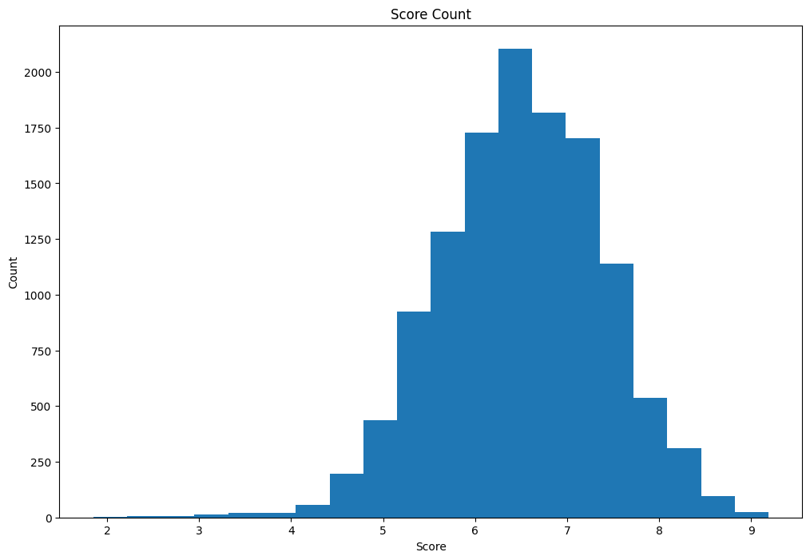

```python
plt.figure(figsize=(12,8))
# Create a histogram
plt.hist(anime["Score"], bins=20)

# Add labels to the plot
plt.xlabel("Score")
plt.ylabel("Count")
plt.title("Score Count")
# Show the plot
plt.show()
```

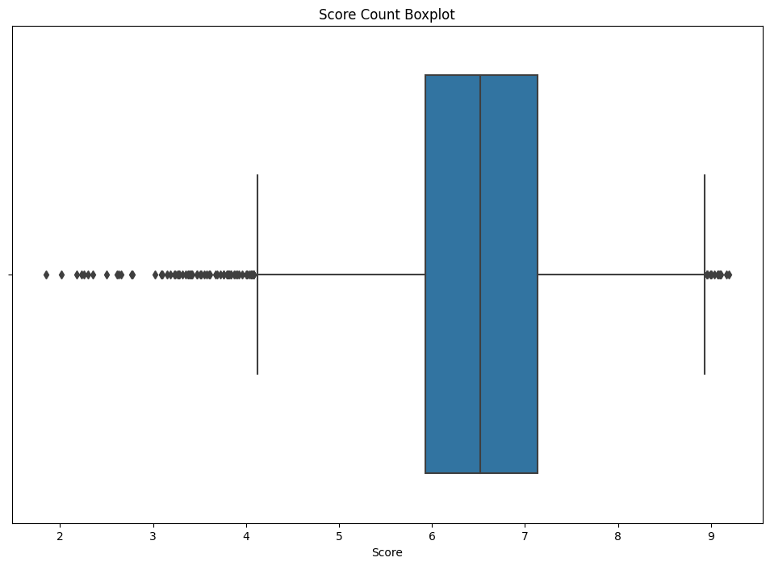

```python
plt.figure(figsize=(12,8))
# Create a bar plot
sns.boxplot(x="Score", data=anime)
plt.title("Score Count Boxplot")
# Show the plot
plt.show()
```

The both score plots shows the distribution of scores for all anime titles in the dataset. From the plot, we can see that the majority of anime titles have scores between 5 and 8, with a smaller number of titles having scores below 5 or above 8. This suggests that the majority of anime titles are considered to be of average quality, with relatively fewer titles that are highly rated or poorly rated.

There are several possible explanations for this pattern. One possibility is that the average quality of anime titles has remained relatively consistent over time, with only a small proportion being exceptional or subpar. Another possibility is that there may be biases in the ratings, such as a tendency for users to give higher scores to certain genres or studios, or a tendency to rate more recent titles higher due to nostalgia or hype.

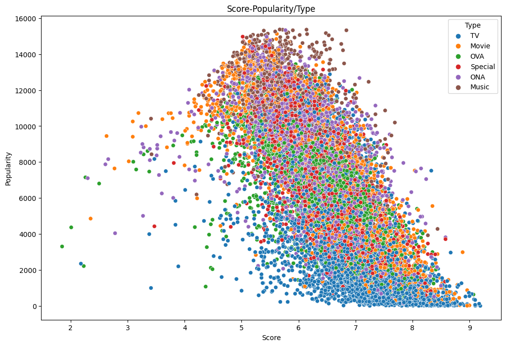

```python
plt.figure(figsize=(12,8))
# Create a scatter plot with the Type column as the hue
sns.scatterplot(x="Score", y="Popularity", hue="Type", data=anime)
plt.title("Score-Popularity/Type")
# Show the plot
plt.show()
```

Overall, this plot highlights the complexity of the relationship between score and popularity in the anime industry, and suggests that there may be multiple factors at play.

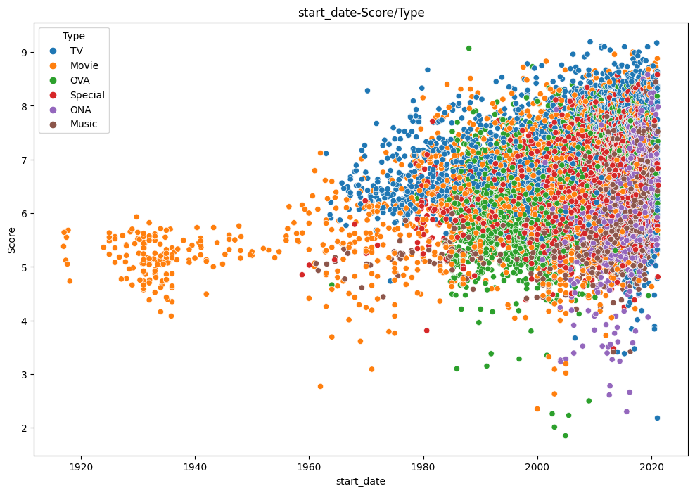

```python
plt.figure(figsize=(12,8))
# Create a scatter plot
sns.scatterplot(x="start_date", y="Score", hue="Type", data=anime)
plt.title("start_date-Score/Type")
# Show the plot
plt.show()
```

The scatter plot shows the relationship between the start date and score of anime titles, colored by type. From the plot, we can see that there has been a steady increase in the number of anime titles released over the past 60 years, with a particularly sharp increase in the past 20 years. This suggests that the anime industry has experienced significant growth and expansion in recent years.

The plot also shows that the quality of anime titles, as measured by their scores, has generally improved over time. This is indicated by the higher concentration of points with higher scores in more recent years. This could be due to a variety of factors, such as advancements in animation technology, increased competition and demand for high-quality content, or a shift in audience preferences.

It is also worth noting that the majority of anime titles released before the 1960s are of the movie type, while more recent titles are more diverse in terms of type. This could be due to the evolution of the anime industry and the introduction of new formats and distribution channels.

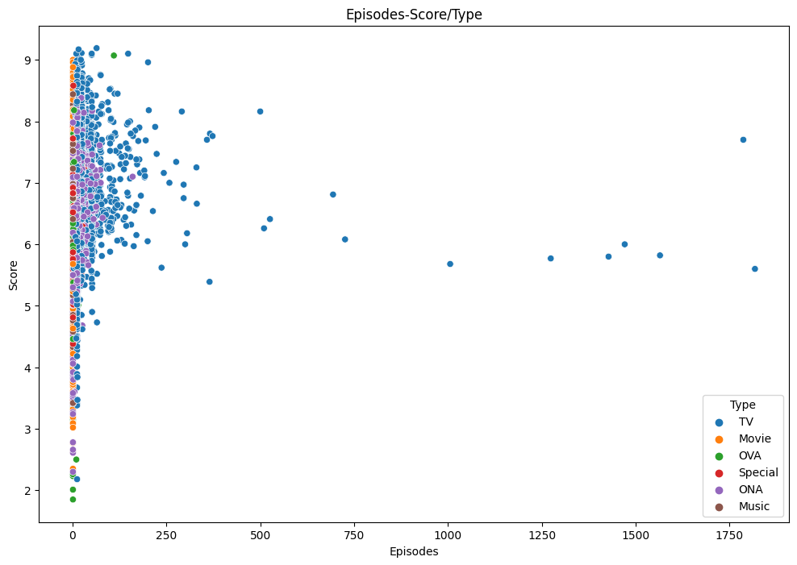

```python
plt.figure(figsize=(12,8))
# Create a scatter plot
sns.scatterplot(x="Episodes", y="Score", hue="Type", data=anime)
plt.title("Episodes-Score/Type")
# Show the plot
plt.show()
```

The scatter plot shows the relationship between the number of episodes and score of anime titles, colored by type. From the plot, we can see that the majority of anime titles have fewer than 200 episodes, with a small number of titles having more than 200 episodes. This suggests that most anime titles are relatively short, with only a small proportion being long-running series.

It is worth noting that there are some exceptions to this trend, such as some long-running series that have relatively high scores despite their large episode count. These could be examples of exceptional or highly popular series that have managed to maintain a high level of quality and engagement over a longer period.

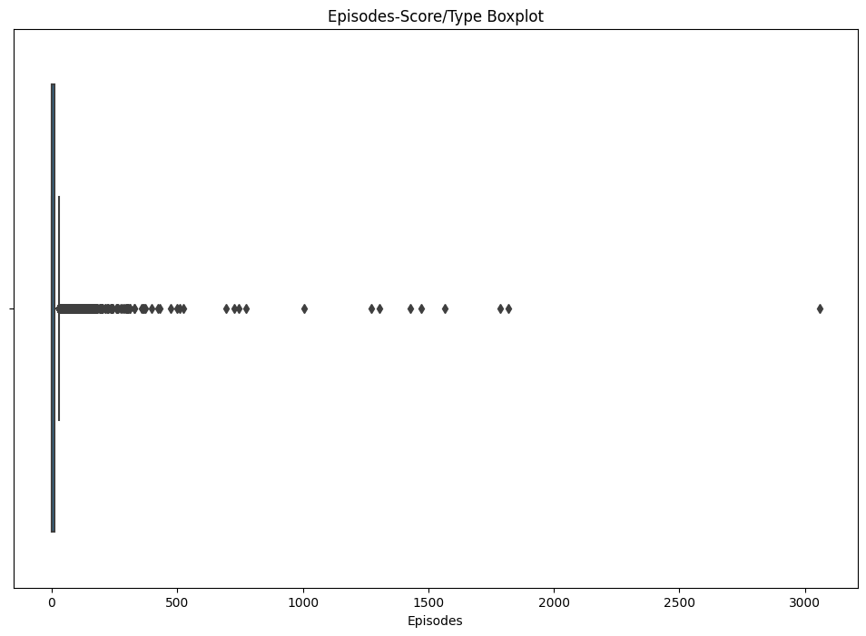

```python
plt.figure(figsize=(12,8))
# Create a box plot
sns.boxplot(x="Episodes", data=anime)
plt.title("Episodes-Score/Type Boxplot")
# Show the plot
plt.show()
```

There is particular data that didn't show up in Score/Episodes chart, to find that we use SQL query below, it's Lan Mao.

```python
%%sql
SELECT * FROM anime WHERE Episodes > 1500
;
```

```
 * postgresql://postgres:***@localhost/deneme
4 rows affected.
```

| mal_id | name | score | genres | english_name | japanese_name | type | episodes | premiered | producers | licensors | studios | source | duration | rating | ranked | popularity | members | favorites | watching | completed | on_hold | dropped | plan_to_watch | score_10 | score_9 | score_8 | score_7 | score_6 | score_5 | … |
| --- | --- | --- | --- | --- | --- | --- | --- | --- | --- | --- | --- | --- | --- | --- | --- | --- | --- | --- | --- | --- | --- | --- | --- | --- | --- | --- | --- | --- | --- | --- |
| 2471 | Doraemon (1979) | 7.7 | Adventure, Comedy, Fantasy, Kids, Sci-Fi, Shounen | Doraemon | ドラえもん | TV | 1787.0 | Spring 1979 | TV Asahi, Asatsu DK | None | Shin-Ei Animation | Manga | 11 min. per ep. | PG - Children | 1021.0 | 2598 | 38555 | 401 | 3381 | 21246 | 3622 | 6353 | 3953 | 3827.0 | 3111.0 | 5359.0 | 5775.0 | 2797.0 | 1392.0 | … |
| 9947 | Lan Mao | None | Adventure, Comedy | Blue Cat | 蓝猫 | TV | 3057.0 | Fall 1999 | Beijing Sunchime Happy Culture Company | None | None | Original | 11 min. per ep. | PG - Children | 15271.0 | 11692 | 597 | 0 | 80 | 93 | 35 | 212 | 177 | 13.0 | 5.0 | 9.0 | 20.0 | 20.0 | 32.0 | … |
| 12393 | Oyako Club | 5.6 | Slice of Life, Comedy | None | 親子クラブ | TV | 1818.0 | Fall 1994 | Fuji TV | None | Eiken | Original | 5 min. per ep. | G - All Ages | 9440.0 | 11257 | 716 | 0 | 39 | 428 | 17 | 99 | 133 | 33.0 | 9.0 | 12.0 | 25.0 | 43.0 | 60.0 | … |
| 23349 | Kirin Monoshiri Yakata | 5.82 | Kids | None | キリンものしり館 | TV | 1565.0 | Winter 1975 | Mainichi Broadcasting System | None | None | None | 5 min. per ep. | PG - Children | 8779.0 | 12523 | 433 | 1 | 17 | 263 | 14 | 70 | 69 | 19.0 | 3.0 | 16.0 | 11.0 | 22.0 | 30.0 | … |

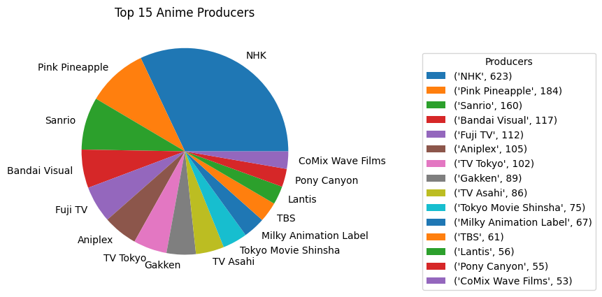

```python
top_n = 15
counts = anime["Producers"].value_counts()[:top_n]

# Create the pie chart
plt.pie(counts, labels=counts.index)

# Create a list of label and count pairs
label_counts = [(label, count) for label, count in zip(counts.index, counts)]

plt.title("Top 15 Anime Producers")

# Create the legend using the label_counts list
plt.legend(label_counts, title="Producers", bbox_to_anchor=(1.4, 0.9))

# Show the plot
plt.show()
```

```python
%%sql
SELECT COALESCE(producers, 'Unknown') AS producer, AVG(score) AS avg_score
FROM anime
GROUP BY producer
HAVING COUNT(*) >= 15
ORDER BY avg_score DESC
LIMIT 15;
```

```
 * postgresql://postgres:***@localhost/deneme
15 rows affected.
```

| producer | avg_score |
| --- | --- |
| VAP, Nippon Television Network | 7.507894766958136 |
| Shochiku | 7.415882306940415 |
| Tencent Penguin Pictures | 7.369047596341088 |
| Kadokawa | 7.122500061988831 |
| TOHO animation | 7.060000010899135 |
| bilibili | 7.05095234371367 |
| Asahi Broadcasting | 7.037619023095994 |
| Aniplex | 7.005789470672608 |
| TV Asahi | 6.9962711657507946 |
| TV Asahi, Asatsu DK | 6.984999924898148 |
| Studio Jack | 6.967222240236071 |
| Kodansha | 6.955000032078136 |
| Yomiuri Telecasting | 6.954166650772095 |
| Lantis | 6.926538467407227 |
| Pioneer LDC | 6.910500001907349 |

This pie chart shows the top 15 anime producers by the number of anime titles they have produced. The x-axis is divided into wedges, with each wedge representing a different producer. The size of each wedge is proportional to the number of anime titles produced by that producer.

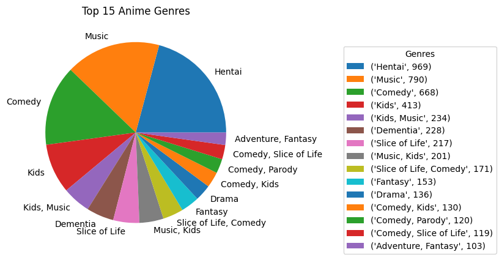

```python
top_n = 15
counts = anime["Genres"].value_counts()[:top_n]

# Create the pie chart
plt.pie(counts, labels=counts.index)

# Create a list of label and count pairs
label_counts = [(label, count) for label, count in zip(counts.index, counts)]

plt.title("Top 15 Anime Genres")

# Create the legend using the label_counts list
plt.legend(label_counts, title="Genres", bbox_to_anchor=(1.4, 0.9))

# Show the plot
plt.show()
```

It is worth noting that the proportions of the pie chart may not reflect the actual popularity of the genres among viewers, as they are based on the number of titles belonging to each genre rather than the number of viewers. For example, a genre with a large number of titles but a small audience could still be represented as a significant slice of the pie.

This chart provides a useful overview of the diversity and balance of genres in the anime industry, and can help identify trends and areas of interest among creators and viewers

```python
%%sql
SELECT AVG(Score) as mean_score, Genres
FROM anime
GROUP BY Genres
HAVING Genres IN (SELECT Genres FROM (
    SELECT Genres, COUNT(*) as count
    FROM anime
    GROUP BY Genres
    ORDER BY count DESC
    LIMIT 10
) top_genres)
```

```
 * postgresql://postgres:***@localhost/deneme
10 rows affected.
```

| mean_score | genres |
| --- | --- |
| 4.853309351763279 | Dementia |
| 6.000666668301537 | Fantasy |
| 5.902264181173073 | Kids |
| 5.338269224533668 | Music, Kids |
| 6.5600000222524 | Slice of Life, Comedy |
| 6.0173253641870925 | Music |
| 6.0600539166329686 | Comedy |
| 5.368333313200209 | Kids, Music |
| 5.708411236789739 | Slice of Life |
| 6.177945773221156 | Hentai |

```python
%%sql
SELECT AVG(COALESCE(Score, 0)) as mean_score, Genres
FROM anime
GROUP BY Genres
ORDER BY mean_score DESC
LIMIT 5
```

```
 * postgresql://postgres:***@localhost/deneme
5 rows affected.
```

| mean_score | genres |
| --- | --- |
| 9.1899995803833 | Action, Military, Adventure, Comedy, Drama, Magic, Fantasy, Shounen |
| 9.109999656677246 | Thriller, Sci-Fi |
| 9.100000381469727 | Action, Drama, Fantasy, Military, Mystery, Shounen, Super Power |
| 9.0 | Drama, School, Shounen |
| 8.960000038146973 | Slice of Life, Comedy, Supernatural, Drama, Romance |

```python
%%sql
SELECT *
FROM anime
WHERE Genres = 'Action, Military, Adventure, Comedy, Drama, Magic, Fantasy, Shounen'
```

```
 * postgresql://postgres:***@localhost/deneme
1 rows affected.
```

| mal_id | name | score | genres | english_name | japanese_name | type | episodes | premiered | producers | licensors | studios | source | duration | rating | ranked | popularity | members | favorites | watching | completed | on_hold | dropped | plan_to_watch | score_10 | score_9 | score_8 | score_7 | score_6 | score_5 | … |
| --- | --- | --- | --- | --- | --- | --- | --- | --- | --- | --- | --- | --- | --- | --- | --- | --- | --- | --- | --- | --- | --- | --- | --- | --- | --- | --- | --- | --- | --- | --- |
| 5114 | Fullmetal Alchemist: Brotherhood | 9.19 | Action, Military, Adventure, Comedy, Drama, Magic, Fantasy, Shounen | Fullmetal Alchemist:Brotherhood | 鋼の錬金術師 FULLMETAL ALCHEMIST | TV | 64.0 | Spring 2009 | Aniplex, Square Enix, Mainichi Broadcasting System, Studio Moriken | Funimation, Aniplex of America | Bones | Manga | 24 min. per ep. | R - 17+ (violence & profanity) | 1.0 | 3 | 2248456 | 183914 | 171871 | 1644938 | 75728 | 32456 | 323463 | 714811.0 | 401507.0 | 199160.0 | 70045.0 | 20210.0 | 9308.0 | … |

```python
%%sql
SELECT *
FROM anime
WHERE Genres = 'Thriller, Sci-Fi'
```

```
 * postgresql://postgres:***@localhost/deneme
1 rows affected.
```

| mal_id | name | score | genres | english_name | japanese_name | type | episodes | premiered | producers | licensors | studios | source | duration | rating | ranked | popularity | members | favorites | watching | completed | on_hold | dropped | plan_to_watch | score_10 | score_9 | score_8 | score_7 | score_6 | score_5 | … |
| --- | --- | --- | --- | --- | --- | --- | --- | --- | --- | --- | --- | --- | --- | --- | --- | --- | --- | --- | --- | --- | --- | --- | --- | --- | --- | --- | --- | --- | --- | --- |
| 9253 | Steins;Gate | 9.11 | Thriller, Sci-Fi | Steins;Gate | STEINS;GATE | TV | 24.0 | Spring 2011 | Frontier Works, Media Factory, Movic, AT-X, Kadokawa Pictures Japan, Nitroplus | Funimation | White Fox | Visual novel | 24 min. per ep. | PG-13 - Teens 13 or older | 3.0 | 9 | 1771162 | 148452 | 114349 | 1134756 | 60926 | 35600 | 425531 | 468504.0 | 275960.0 | 140914.0 | 57740.0 | 21375.0 | 11126.0 | … |

```python
%%sql
SELECT *
FROM anime
WHERE Genres = 'Drama, School, Shounen'
```

```
 * postgresql://postgres:***@localhost/deneme
1 rows affected.
```

| mal_id | name | score | genres | english_name | japanese_name | type | episodes | premiered | producers | licensors | studios | source | duration | rating | ranked | popularity | members | favorites | watching | completed | on_hold | dropped | plan_to_watch | score_10 | score_9 | score_8 | score_7 | score_6 | score_5 | … |
| --- | --- | --- | --- | --- | --- | --- | --- | --- | --- | --- | --- | --- | --- | --- | --- | --- | --- | --- | --- | --- | --- | --- | --- | --- | --- | --- | --- | --- | --- | --- |
| 28851 | Koe no Katachi | 9.0 | Drama, School, Shounen | A Silent Voice | 聲の形 | Movie | 1.0 | None | Shochiku, Pony Canyon, Kodansha, ABC Animation, Quaras | Eleven Arts, NYAV Post | Kyoto Animation | Manga | 2 hr. 10 min. | PG-13 - Teens 13 or older | 11.0 | 28 | 1387607 | 62452 | 30379 | 1151644 | 4306 | 1949 | 199329 | 393684.0 | 295492.0 | 156604.0 | 61581.0 | 19228.0 | 7135.0 | … |

```python
%%sql
SELECT a.name, a.score, a.genres, a.type, aws.sypnopsis, al.rating, al.watching_status
FROM anime a
JOIN anime_with_synopsis aws ON a.mal_id = aws.mal_id
JOIN animelist al ON a.mal_id = al.anime_id
WHERE a.score > 9
LIMIT 10;
```

```
 * postgresql://postgres:***@localhost/deneme
10 rows affected.
```

| name | score | genres | type | sypnopsis | rating | watching_status |
| --- | --- | --- | --- | --- | --- | --- |
| Fullmetal Alchemist: Brotherhood | 9.19 | Action, Military, Adventure, Comedy, Drama, Magic, Fantasy, Shounen | TV | In order for something to be obtained, something of equal value must be lost. Alchemy is bound by this Law of Equivalent Exchange—something the young brothers Edward and Alphonse Elric only realize af… | 0.0 | 6.0 |
| Shingeki no Kyojin Season 3 Part 2 | 9.1 | Action, Drama, Fantasy, Military, Mystery, Shounen, Super Power | TV | Seeking to restore humanity's diminishing hope, the Survey Corps embark on a mission to retake Wall Maria, where the battle against the merciless Titans takes the stage once again. Returning to the ta… | 0.0 | 6.0 |
| Shingeki no Kyojin: The Final Season | 9.17 | Action, Military, Mystery, Super Power, Drama, Fantasy, Shounen | TV | Gabi Braun and Falco Grice have been training their entire lives to inherit one of the seven titans under Marley's control and aid their nation in eradicating the Eldians on Paradis. However, just as … | 0.0 | 6.0 |
| Steins;Gate | 9.11 | Thriller, Sci-Fi | TV | The self-proclaimed mad scientist Rintarou Okabe rents out a room in a rickety old building in Akihabara, where he indulges himself in his hobby of inventing prospective future gadgets with fellow lab… | 0.0 | 6.0 |
| Fullmetal Alchemist: Brotherhood | 9.19 | Action, Military, Adventure, Comedy, Drama, Magic, Fantasy, Shounen | TV | In order for something to be obtained, something of equal value must be lost. Alchemy is bound by this Law of Equivalent Exchange—something the young brothers Edward and Alphonse Elric only realize af… | 10.0 | 2.0 |
| Shingeki no Kyojin Season 3 Part 2 | 9.1 | Action, Drama, Fantasy, Military, Mystery, Shounen, Super Power | TV | Seeking to restore humanity's diminishing hope, the Survey Corps embark on a mission to retake Wall Maria, where the battle against the merciless Titans takes the stage once again. Returning to the ta… | 0.0 | 2.0 |
| Steins;Gate | 9.11 | Thriller, Sci-Fi | TV | The self-proclaimed mad scientist Rintarou Okabe rents out a room in a rickety old building in Akihabara, where he indulges himself in his hobby of inventing prospective future gadgets with fellow lab… | 10.0 | 2.0 |
| Gintama' | 9.08 | Action, Sci-Fi, Comedy, Historical, Parody, Samurai, Shounen | TV | fter a one-year hiatus, Shinpachi Shimura returns to Edo, only to stumble upon a shocking surprise: Gintoki and Kagura, his fellow Yorozuya members, have become completely different characters! Fleein… | 9.0 | 2.0 |
| Fullmetal Alchemist: Brotherhood | 9.19 | Action, Military, Adventure, Comedy, Drama, Magic, Fantasy, Shounen | TV | In order for something to be obtained, something of equal value must be lost. Alchemy is bound by this Law of Equivalent Exchange—something the young brothers Edward and Alphonse Elric only realize af… | 0.0 | 6.0 |
| Hunter x Hunter (2011) | 9.1 | Action, Adventure, Fantasy, Shounen, Super Power | TV | Hunter x Hunter is set in a world where Hunters exist to perform all manner of dangerous tasks like capturing criminals and bravely searching for lost treasures in uncharted territories. Twelve-year-o… | 0.0 | 6.0 |

Overall, this EDA has provided valuable insights into the anime community and has identified several areas for further study. Some potential next steps could include analyzing user ratings and preferences to better understand the factors that contribute to the popularity and success of anime titles. These insights can be used to inform the production and distribution of anime, as well as to help users discover new and highly rated titles.